# Home Credit EDA

### Submitted by: Michael Mendoza

#### October 8, 2023

# Table of Contents:

- Importing Libraries
- Introduction
- Loading the Data
- Describing the data
- Missing Data Discussion
- Data Balance
- Target Variable Relationships
- Merging Application Train & Bureau Datasets
- Results

# Introduction

Home Credit customers that have insufficient or no-credit histories that are capable of repaying their loans are being rejected automatically by their systems. This problem poses a loss of potential customers, in turn loss of potential revenue who could have been able to repay their loan and be a customer of Home Credit. Since this is a question of which clients are likely to repay loans, a predictive analytics approach is needed. A classification model will be used to analyze a variety of alternative data of a given customer and will output a probability of individuals who have a potential to repay a loan.

This EDA notebook will explore what available variables are in the datasets. It includes checking with missing data and addressing how to impute and remove columns as necessary. We will explore the relationships with some important variables that relates to the Target variable which is Default.

# Importing Libraries

```python
import pandas as pd
import numpy as np
import matplotlib.pyplot as plt
import matplotlib.ticker as mtick
```

# Loading the Data

```python
app_train_data = pd.read_csv("data/application_train.csv")
app_test_data = pd.read_csv("data/application_test.csv")
previous_application_data = pd.read_csv("data/previous_application.csv")
installments_payments_data = pd.read_csv("data/installments_payments.csv")
bureau_data = pd.read_csv("data/bureau.csv")
bureau_balance_data = pd.read_csv("data/bureau_balance.csv")
credit_card_balance_data = pd.read_csv("data/credit_card_balance.csv")
pos_cash_balance_data = pd.read_csv("data/POS_CASH_balance.csv")
```

# Describing the data

Questions:

1. How many columns and rows are there in the data?
2. Is there potential missing data that needs more discussion and digging?
3. Any column names that needs to be corrected? (i.e. Spelling)

```python
#pd.set_option('display.max_rows', None)
def describe_data(data):
    print("Columns:", data.shape[1])
    print("Rows:", data.shape[0])
    return data.describe().transpose()
```

```python
# application_train.csv
describe_data(app_train_data)
```

```
Columns: 122
Rows: 307511
```

|  | count | mean | std | min | 25% | 50% | 75% | max |
| --- | --- | --- | --- | --- | --- | --- | --- | --- |
| SK_ID_CURR | 307511.0 | 278180.518577 | 102790.175348 | 100002.0 | 189145.5 | 278202.0 | 367142.5 | 456255.0 |
| TARGET | 307511.0 | 0.080729 | 0.272419 | 0.0 | 0.0 | 0.0 | 0.0 | 1.0 |
| CNT_CHILDREN | 307511.0 | 0.417052 | 0.722121 | 0.0 | 0.0 | 0.0 | 1.0 | 19.0 |
| AMT_INCOME_TOTAL | 307511.0 | 168797.919297 | 237123.146279 | 25650.0 | 112500.0 | 147150.0 | 202500.0 | 117000000.0 |
| AMT_CREDIT | 307511.0 | 599025.999706 | 402490.776996 | 45000.0 | 270000.0 | 513531.0 | 808650.0 | 4050000.0 |
| ... | ... | ... | ... | ... | ... | ... | ... | ... |
| AMT_REQ_CREDIT_BUREAU_DAY | 265992.0 | 0.007000 | 0.110757 | 0.0 | 0.0 | 0.0 | 0.0 | 9.0 |
| AMT_REQ_CREDIT_BUREAU_WEEK | 265992.0 | 0.034362 | 0.204685 | 0.0 | 0.0 | 0.0 | 0.0 | 8.0 |
| AMT_REQ_CREDIT_BUREAU_MON | 265992.0 | 0.267395 | 0.916002 | 0.0 | 0.0 | 0.0 | 0.0 | 27.0 |
| AMT_REQ_CREDIT_BUREAU_QRT | 265992.0 | 0.265474 | 0.794056 | 0.0 | 0.0 | 0.0 | 0.0 | 261.0 |
| AMT_REQ_CREDIT_BUREAU_YEAR | 265992.0 | 1.899974 | 1.869295 | 0.0 | 0.0 | 1.0 | 3.0 | 25.0 |

106 rows × 8 columns

**Quick look:** Application train data is a big dataset. A quick glimpse shows discrepances on row count of each column which suggest missing data. It needs to be cleaned and further discussed on the missing data discussion section. Column names are clear and understandable.

```python
# application_test.csv
describe_data(app_test_data)
```

```
Columns: 121
Rows: 48744
```

|  | count | mean | std | min | 25% | 50% | 75% | max |
| --- | --- | --- | --- | --- | --- | --- | --- | --- |
| SK_ID_CURR | 48744.0 | 277796.676350 | 103169.547296 | 100001.0 | 188557.75 | 277549.0 | 367555.5 | 456250.0 |
| CNT_CHILDREN | 48744.0 | 0.397054 | 0.709047 | 0.0 | 0.00 | 0.0 | 1.0 | 20.0 |
| AMT_INCOME_TOTAL | 48744.0 | 178431.805855 | 101522.591536 | 26941.5 | 112500.00 | 157500.0 | 225000.0 | 4410000.0 |
| AMT_CREDIT | 48744.0 | 516740.435561 | 365397.004174 | 45000.0 | 260640.00 | 450000.0 | 675000.0 | 2245500.0 |
| AMT_ANNUITY | 48720.0 | 29426.240209 | 16016.368315 | 2295.0 | 17973.00 | 26199.0 | 37390.5 | 180576.0 |
| ... | ... | ... | ... | ... | ... | ... | ... | ... |
| AMT_REQ_CREDIT_BUREAU_DAY | 42695.0 | 0.001803 | 0.046132 | 0.0 | 0.00 | 0.0 | 0.0 | 2.0 |
| AMT_REQ_CREDIT_BUREAU_WEEK | 42695.0 | 0.002787 | 0.054037 | 0.0 | 0.00 | 0.0 | 0.0 | 2.0 |
| AMT_REQ_CREDIT_BUREAU_MON | 42695.0 | 0.009299 | 0.110924 | 0.0 | 0.00 | 0.0 | 0.0 | 6.0 |
| AMT_REQ_CREDIT_BUREAU_QRT | 42695.0 | 0.546902 | 0.693305 | 0.0 | 0.00 | 0.0 | 1.0 | 7.0 |
| AMT_REQ_CREDIT_BUREAU_YEAR | 42695.0 | 1.983769 | 1.838873 | 0.0 | 0.00 | 2.0 | 3.0 | 17.0 |

105 rows × 8 columns

**Quick look:** Application test data looks similar with the train data with the exception of the TARGET variable as expected. It does contain a siginifcant amount of missing data which will be further discussed below.

```python
# previous_application.csv
describe_data(previous_application_data)
```

```
Columns: 37
Rows: 1670214
```

|  | count | mean | std | min | 25% | 50% | 75% | max |
| --- | --- | --- | --- | --- | --- | --- | --- | --- |
| SK_ID_PREV | 1670214.0 | 1.923089e+06 | 532597.958696 | 1.000001e+06 | 1.461857e+06 | 1.923110e+06 | 2.384280e+06 | 2845382.000 |
| SK_ID_CURR | 1670214.0 | 2.783572e+05 | 102814.823849 | 1.000010e+05 | 1.893290e+05 | 2.787145e+05 | 3.675140e+05 | 456255.000 |
| AMT_ANNUITY | 1297979.0 | 1.595512e+04 | 14782.137335 | 0.000000e+00 | 6.321780e+03 | 1.125000e+04 | 2.065842e+04 | 418058.145 |
| AMT_APPLICATION | 1670214.0 | 1.752339e+05 | 292779.762387 | 0.000000e+00 | 1.872000e+04 | 7.104600e+04 | 1.803600e+05 | 6905160.000 |
| AMT_CREDIT | 1670213.0 | 1.961140e+05 | 318574.616546 | 0.000000e+00 | 2.416050e+04 | 8.054100e+04 | 2.164185e+05 | 6905160.000 |
| AMT_DOWN_PAYMENT | 774370.0 | 6.697402e+03 | 20921.495410 | -9.000000e-01 | 0.000000e+00 | 1.638000e+03 | 7.740000e+03 | 3060045.000 |
| AMT_GOODS_PRICE | 1284699.0 | 2.278473e+05 | 315396.557937 | 0.000000e+00 | 5.084100e+04 | 1.123200e+05 | 2.340000e+05 | 6905160.000 |
| HOUR_APPR_PROCESS_START | 1670214.0 | 1.248418e+01 | 3.334028 | 0.000000e+00 | 1.000000e+01 | 1.200000e+01 | 1.500000e+01 | 23.000 |
| NFLAG_LAST_APPL_IN_DAY | 1670214.0 | 9.964675e-01 | 0.059330 | 0.000000e+00 | 1.000000e+00 | 1.000000e+00 | 1.000000e+00 | 1.000 |
| RATE_DOWN_PAYMENT | 774370.0 | 7.963682e-02 | 0.107823 | -1.497876e-05 | 0.000000e+00 | 5.160508e-02 | 1.089091e-01 | 1.000 |
| RATE_INTEREST_PRIMARY | 5951.0 | 1.883569e-01 | 0.087671 | 3.478125e-02 | 1.607163e-01 | 1.891222e-01 | 1.933299e-01 | 1.000 |
| RATE_INTEREST_PRIVILEGED | 5951.0 | 7.735025e-01 | 0.100879 | 3.731501e-01 | 7.156448e-01 | 8.350951e-01 | 8.525370e-01 | 1.000 |
| DAYS_DECISION | 1670214.0 | -8.806797e+02 | 779.099667 | -2.922000e+03 | -1.300000e+03 | -5.810000e+02 | -2.800000e+02 | -1.000 |
| SELLERPLACE_AREA | 1670214.0 | 3.139511e+02 | 7127.443459 | -1.000000e+00 | -1.000000e+00 | 3.000000e+00 | 8.200000e+01 | 4000000.000 |
| CNT_PAYMENT | 1297984.0 | 1.605408e+01 | 14.567288 | 0.000000e+00 | 6.000000e+00 | 1.200000e+01 | 2.400000e+01 | 84.000 |
| DAYS_FIRST_DRAWING | 997149.0 | 3.422099e+05 | 88916.115834 | -2.922000e+03 | 3.652430e+05 | 3.652430e+05 | 3.652430e+05 | 365243.000 |
| DAYS_FIRST_DUE | 997149.0 | 1.382627e+04 | 72444.869708 | -2.892000e+03 | -1.628000e+03 | -8.310000e+02 | -4.110000e+02 | 365243.000 |
| DAYS_LAST_DUE_1ST_VERSION | 997149.0 | 3.376777e+04 | 106857.034789 | -2.801000e+03 | -1.242000e+03 | -3.610000e+02 | 1.290000e+02 | 365243.000 |
| DAYS_LAST_DUE | 997149.0 | 7.658240e+04 | 149647.415123 | -2.889000e+03 | -1.314000e+03 | -5.370000e+02 | -7.400000e+01 | 365243.000 |
| DAYS_TERMINATION | 997149.0 | 8.199234e+04 | 153303.516729 | -2.874000e+03 | -1.270000e+03 | -4.990000e+02 | -4.400000e+01 | 365243.000 |
| NFLAG_INSURED_ON_APPROVAL | 997149.0 | 3.325702e-01 | 0.471134 | 0.000000e+00 | 0.000000e+00 | 0.000000e+00 | 1.000000e+00 | 1.000 |

**Quick look:** Previous application data is not as wide as the current application dataset. SK_ID_CURR can be used to merge to the application train dataset for further analysis. There are signs of missing data but not as much as the first datasets.

```python
# installments_payments.csv
describe_data(installments_payments_data)
```

```
Columns: 8
Rows: 13605401
```

|  | count | mean | std | min | 25% | 50% | 75% | max |
| --- | --- | --- | --- | --- | --- | --- | --- | --- |
| SK_ID_PREV | 13605401.0 | 1.903365e+06 | 536202.905546 | 1000001.0 | 1434191.000 | 1896520.000 | 2369094.000 | 2843499.000 |
| SK_ID_CURR | 13605401.0 | 2.784449e+05 | 102718.310411 | 100001.0 | 189639.000 | 278685.000 | 367530.000 | 456255.000 |
| NUM_INSTALMENT_VERSION | 13605401.0 | 8.566373e-01 | 1.035216 | 0.0 | 0.000 | 1.000 | 1.000 | 178.000 |
| NUM_INSTALMENT_NUMBER | 13605401.0 | 1.887090e+01 | 26.664067 | 1.0 | 4.000 | 8.000 | 19.000 | 277.000 |
| DAYS_INSTALMENT | 13605401.0 | -1.042270e+03 | 800.946284 | -2922.0 | -1654.000 | -818.000 | -361.000 | -1.000 |
| DAYS_ENTRY_PAYMENT | 13602496.0 | -1.051114e+03 | 800.585883 | -4921.0 | -1662.000 | -827.000 | -370.000 | -1.000 |
| AMT_INSTALMENT | 13605401.0 | 1.705091e+04 | 50570.254429 | 0.0 | 4226.085 | 8884.080 | 16710.210 | 3771487.845 |
| AMT_PAYMENT | 13602496.0 | 1.723822e+04 | 54735.783981 | 0.0 | 3398.265 | 8125.515 | 16108.425 | 3771487.845 |

```python
# bureau.csv
describe_data(bureau_data)
```

```
Columns: 17
Rows: 1716428
```

|  | count | mean | std | min | 25% | 50% | 75% | max |
| --- | --- | --- | --- | --- | --- | --- | --- | --- |
| SK_ID_CURR | 1716428.0 | 2.782149e+05 | 1.029386e+05 | 100001.000 | 188866.75 | 278055.0 | 367426.00 | 4.562550e+05 |
| SK_ID_BUREAU | 1716428.0 | 5.924434e+06 | 5.322657e+05 | 5000000.000 | 5463953.75 | 5926303.5 | 6385681.25 | 6.843457e+06 |
| DAYS_CREDIT | 1716428.0 | -1.142108e+03 | 7.951649e+02 | -2922.000 | -1666.00 | -987.0 | -474.00 | 0.000000e+00 |
| CREDIT_DAY_OVERDUE | 1716428.0 | 8.181666e-01 | 3.654443e+01 | 0.000 | 0.00 | 0.0 | 0.00 | 2.792000e+03 |
| DAYS_CREDIT_ENDDATE | 1610875.0 | 5.105174e+02 | 4.994220e+03 | -42060.000 | -1138.00 | -330.0 | 474.00 | 3.119900e+04 |
| DAYS_ENDDATE_FACT | 1082775.0 | -1.017437e+03 | 7.140106e+02 | -42023.000 | -1489.00 | -897.0 | -425.00 | 0.000000e+00 |
| AMT_CREDIT_MAX_OVERDUE | 591940.0 | 3.825418e+03 | 2.060316e+05 | 0.000 | 0.00 | 0.0 | 0.00 | 1.159872e+08 |
| CNT_CREDIT_PROLONG | 1716428.0 | 6.410406e-03 | 9.622391e-02 | 0.000 | 0.00 | 0.0 | 0.00 | 9.000000e+00 |
| AMT_CREDIT_SUM | 1716415.0 | 3.549946e+05 | 1.149811e+06 | 0.000 | 51300.00 | 125518.5 | 315000.00 | 5.850000e+08 |
| AMT_CREDIT_SUM_DEBT | 1458759.0 | 1.370851e+05 | 6.774011e+05 | -4705600.320 | 0.00 | 0.0 | 40153.50 | 1.701000e+08 |
| AMT_CREDIT_SUM_LIMIT | 1124648.0 | 6.229515e+03 | 4.503203e+04 | -586406.115 | 0.00 | 0.0 | 0.00 | 4.705600e+06 |
| AMT_CREDIT_SUM_OVERDUE | 1716428.0 | 3.791276e+01 | 5.937650e+03 | 0.000 | 0.00 | 0.0 | 0.00 | 3.756681e+06 |
| DAYS_CREDIT_UPDATE | 1716428.0 | -5.937483e+02 | 7.207473e+02 | -41947.000 | -908.00 | -395.0 | -33.00 | 3.720000e+02 |
| AMT_ANNUITY | 489637.0 | 1.571276e+04 | 3.258269e+05 | 0.000 | 0.00 | 0.0 | 13500.00 | 1.184534e+08 |

```python
# bureau_balance.csv
describe_data(bureau_balance_data)
```

```
Columns: 3
Rows: 27299925
```

|  | count | mean | std | min | 25% | 50% | 75% | max |
| --- | --- | --- | --- | --- | --- | --- | --- | --- |
| SK_ID_BUREAU | 27299925.0 | 6.036297e+06 | 492348.856904 | 5001709.0 | 5730933.0 | 6070821.0 | 6431951.0 | 6842888.0 |
| MONTHS_BALANCE | 27299925.0 | -3.074169e+01 | 23.864509 | -96.0 | -46.0 | -25.0 | -11.0 | 0.0 |

```python
# credit_card_balance.csv
describe_data(credit_card_balance_data)
```

```
Columns: 23
Rows: 3840312
```

|  | count | mean | std | min | 25% | 50% | 75% | max |
| --- | --- | --- | --- | --- | --- | --- | --- | --- |
| SK_ID_PREV | 3840312.0 | 1.904504e+06 | 536469.470563 | 1000018.000 | 1434385.00 | 1897122.0 | 2.369328e+06 | 2843496.000 |
| SK_ID_CURR | 3840312.0 | 2.783242e+05 | 102704.475133 | 100006.000 | 189517.00 | 278396.0 | 3.675800e+05 | 456250.000 |
| MONTHS_BALANCE | 3840312.0 | -3.452192e+01 | 26.667751 | -96.000 | -55.00 | -28.0 | -1.100000e+01 | -1.000 |
| AMT_BALANCE | 3840312.0 | 5.830016e+04 | 106307.031025 | -420250.185 | 0.00 | 0.0 | 8.904669e+04 | 1505902.185 |
| AMT_CREDIT_LIMIT_ACTUAL | 3840312.0 | 1.538080e+05 | 165145.699523 | 0.000 | 45000.00 | 112500.0 | 1.800000e+05 | 1350000.000 |
| AMT_DRAWINGS_ATM_CURRENT | 3090496.0 | 5.961325e+03 | 28225.688579 | -6827.310 | 0.00 | 0.0 | 0.000000e+00 | 2115000.000 |
| AMT_DRAWINGS_CURRENT | 3840312.0 | 7.433388e+03 | 33846.077334 | -6211.620 | 0.00 | 0.0 | 0.000000e+00 | 2287098.315 |
| AMT_DRAWINGS_OTHER_CURRENT | 3090496.0 | 2.881696e+02 | 8201.989345 | 0.000 | 0.00 | 0.0 | 0.000000e+00 | 1529847.000 |
| AMT_DRAWINGS_POS_CURRENT | 3090496.0 | 2.968805e+03 | 20796.887047 | 0.000 | 0.00 | 0.0 | 0.000000e+00 | 2239274.160 |
| AMT_INST_MIN_REGULARITY | 3535076.0 | 3.540204e+03 | 5600.154122 | 0.000 | 0.00 | 0.0 | 6.633911e+03 | 202882.005 |
| AMT_PAYMENT_CURRENT | 3072324.0 | 1.028054e+04 | 36078.084953 | 0.000 | 152.37 | 2702.7 | 9.000000e+03 | 4289207.445 |
| AMT_PAYMENT_TOTAL_CURRENT | 3840312.0 | 7.588857e+03 | 32005.987768 | 0.000 | 0.00 | 0.0 | 6.750000e+03 | 4278315.690 |
| AMT_RECEIVABLE_PRINCIPAL | 3840312.0 | 5.596588e+04 | 102533.616843 | -423305.820 | 0.00 | 0.0 | 8.535924e+04 | 1472316.795 |
| AMT_RECIVABLE | 3840312.0 | 5.808881e+04 | 105965.369908 | -420250.185 | 0.00 | 0.0 | 8.889949e+04 | 1493338.185 |
| AMT_TOTAL_RECEIVABLE | 3840312.0 | 5.809829e+04 | 105971.801103 | -420250.185 | 0.00 | 0.0 | 8.891451e+04 | 1493338.185 |
| CNT_DRAWINGS_ATM_CURRENT | 3090496.0 | 3.094490e-01 | 1.100401 | 0.000 | 0.00 | 0.0 | 0.000000e+00 | 51.000 |
| CNT_DRAWINGS_CURRENT | 3840312.0 | 7.031439e-01 | 3.190347 | 0.000 | 0.00 | 0.0 | 0.000000e+00 | 165.000 |
| CNT_DRAWINGS_OTHER_CURRENT | 3090496.0 | 4.812496e-03 | 0.082639 | 0.000 | 0.00 | 0.0 | 0.000000e+00 | 12.000 |
| CNT_DRAWINGS_POS_CURRENT | 3090496.0 | 5.594791e-01 | 3.240649 | 0.000 | 0.00 | 0.0 | 0.000000e+00 | 165.000 |
| CNT_INSTALMENT_MATURE_CUM | 3535076.0 | 2.082508e+01 | 20.051494 | 0.000 | 4.00 | 15.0 | 3.200000e+01 | 120.000 |
| SK_DPD | 3840312.0 | 9.283667e+00 | 97.515700 | 0.000 | 0.00 | 0.0 | 0.000000e+00 | 3260.000 |
| SK_DPD_DEF | 3840312.0 | 3.316220e-01 | 21.479231 | 0.000 | 0.00 | 0.0 | 0.000000e+00 | 3260.000 |

```python
# previous_application.csv
describe_data(previous_application_data)
```

```
Columns: 37
Rows: 1670214
```

|  | count | mean | std | min | 25% | 50% | 75% | max |
| --- | --- | --- | --- | --- | --- | --- | --- | --- |
| SK_ID_PREV | 1670214.0 | 1.923089e+06 | 532597.958696 | 1.000001e+06 | 1.461857e+06 | 1.923110e+06 | 2.384280e+06 | 2845382.000 |
| SK_ID_CURR | 1670214.0 | 2.783572e+05 | 102814.823849 | 1.000010e+05 | 1.893290e+05 | 2.787145e+05 | 3.675140e+05 | 456255.000 |
| AMT_ANNUITY | 1297979.0 | 1.595512e+04 | 14782.137335 | 0.000000e+00 | 6.321780e+03 | 1.125000e+04 | 2.065842e+04 | 418058.145 |
| AMT_APPLICATION | 1670214.0 | 1.752339e+05 | 292779.762387 | 0.000000e+00 | 1.872000e+04 | 7.104600e+04 | 1.803600e+05 | 6905160.000 |
| AMT_CREDIT | 1670213.0 | 1.961140e+05 | 318574.616546 | 0.000000e+00 | 2.416050e+04 | 8.054100e+04 | 2.164185e+05 | 6905160.000 |
| AMT_DOWN_PAYMENT | 774370.0 | 6.697402e+03 | 20921.495410 | -9.000000e-01 | 0.000000e+00 | 1.638000e+03 | 7.740000e+03 | 3060045.000 |
| AMT_GOODS_PRICE | 1284699.0 | 2.278473e+05 | 315396.557937 | 0.000000e+00 | 5.084100e+04 | 1.123200e+05 | 2.340000e+05 | 6905160.000 |
| HOUR_APPR_PROCESS_START | 1670214.0 | 1.248418e+01 | 3.334028 | 0.000000e+00 | 1.000000e+01 | 1.200000e+01 | 1.500000e+01 | 23.000 |
| NFLAG_LAST_APPL_IN_DAY | 1670214.0 | 9.964675e-01 | 0.059330 | 0.000000e+00 | 1.000000e+00 | 1.000000e+00 | 1.000000e+00 | 1.000 |
| RATE_DOWN_PAYMENT | 774370.0 | 7.963682e-02 | 0.107823 | -1.497876e-05 | 0.000000e+00 | 5.160508e-02 | 1.089091e-01 | 1.000 |
| RATE_INTEREST_PRIMARY | 5951.0 | 1.883569e-01 | 0.087671 | 3.478125e-02 | 1.607163e-01 | 1.891222e-01 | 1.933299e-01 | 1.000 |
| RATE_INTEREST_PRIVILEGED | 5951.0 | 7.735025e-01 | 0.100879 | 3.731501e-01 | 7.156448e-01 | 8.350951e-01 | 8.525370e-01 | 1.000 |
| DAYS_DECISION | 1670214.0 | -8.806797e+02 | 779.099667 | -2.922000e+03 | -1.300000e+03 | -5.810000e+02 | -2.800000e+02 | -1.000 |
| SELLERPLACE_AREA | 1670214.0 | 3.139511e+02 | 7127.443459 | -1.000000e+00 | -1.000000e+00 | 3.000000e+00 | 8.200000e+01 | 4000000.000 |
| CNT_PAYMENT | 1297984.0 | 1.605408e+01 | 14.567288 | 0.000000e+00 | 6.000000e+00 | 1.200000e+01 | 2.400000e+01 | 84.000 |
| DAYS_FIRST_DRAWING | 997149.0 | 3.422099e+05 | 88916.115834 | -2.922000e+03 | 3.652430e+05 | 3.652430e+05 | 3.652430e+05 | 365243.000 |
| DAYS_FIRST_DUE | 997149.0 | 1.382627e+04 | 72444.869708 | -2.892000e+03 | -1.628000e+03 | -8.310000e+02 | -4.110000e+02 | 365243.000 |
| DAYS_LAST_DUE_1ST_VERSION | 997149.0 | 3.376777e+04 | 106857.034789 | -2.801000e+03 | -1.242000e+03 | -3.610000e+02 | 1.290000e+02 | 365243.000 |
| DAYS_LAST_DUE | 997149.0 | 7.658240e+04 | 149647.415123 | -2.889000e+03 | -1.314000e+03 | -5.370000e+02 | -7.400000e+01 | 365243.000 |
| DAYS_TERMINATION | 997149.0 | 8.199234e+04 | 153303.516729 | -2.874000e+03 | -1.270000e+03 | -4.990000e+02 | -4.400000e+01 | 365243.000 |
| NFLAG_INSURED_ON_APPROVAL | 997149.0 | 3.325702e-01 | 0.471134 | 0.000000e+00 | 0.000000e+00 | 0.000000e+00 | 1.000000e+00 | 1.000 |

# Missing Data Discussion

Questions:

1. How much percentage of missing data is in each column?
2. What is the type of the column?
3. Which columns can be removed?
4. Which columns can be imputed? What's the procedure?

```python
def describe_missing_data(data):
    print('Total Columns:', data.shape[1])
    print('Columns with missing data:', data.isnull().any().sum())
    percent = (data.isnull().sum()/data.isnull().count()).sort_values(ascending = False)*100
    types = data.dtypes.to_frame('type')
    return pd.concat([percent], axis = 1, keys=['Percent']).join(types)
```

```python
# application_train.csv
describe_missing_data(app_train_data).query("Percent > 40").head(10)
```

```
Total Columns: 122
Columns with missing data: 67
```

|  | Percent | type |
| --- | --- | --- |
| COMMONAREA_MEDI | 69.872297 | float64 |
| COMMONAREA_AVG | 69.872297 | float64 |
| COMMONAREA_MODE | 69.872297 | float64 |
| NONLIVINGAPARTMENTS_MODE | 69.432963 | float64 |
| NONLIVINGAPARTMENTS_AVG | 69.432963 | float64 |
| NONLIVINGAPARTMENTS_MEDI | 69.432963 | float64 |
| FONDKAPREMONT_MODE | 68.386172 | object |
| LIVINGAPARTMENTS_MODE | 68.354953 | float64 |
| LIVINGAPARTMENTS_AVG | 68.354953 | float64 |
| LIVINGAPARTMENTS_MEDI | 68.354953 | float64 |

**Notes:** Application Train data consists of substantial missing data. 67 columns have been identified and 50 columns have about 40% or above rows that have missing data. With that, we can simply remove these columns rather than imputing on them or deleting rows.

```python
cols = describe_missing_data(app_train_data).query("Percent < 40 and Percent > 0").index.values
app_train_data[cols].describe().transpose()
```

```
Total Columns: 122
Columns with missing data: 67
```

|  | count | mean | std | min | 25% | 50% | 75% | max |
| --- | --- | --- | --- | --- | --- | --- | --- | --- |
| EXT_SOURCE_3 | 246546.0 | 0.510853 | 0.194844 | 5.272652e-04 | 0.370650 | 0.535276 | 0.669057 | 8.960095e-01 |
| AMT_REQ_CREDIT_BUREAU_HOUR | 265992.0 | 0.006402 | 0.083849 | 0.000000e+00 | 0.000000 | 0.000000 | 0.000000 | 4.000000e+00 |
| AMT_REQ_CREDIT_BUREAU_DAY | 265992.0 | 0.007000 | 0.110757 | 0.000000e+00 | 0.000000 | 0.000000 | 0.000000 | 9.000000e+00 |
| AMT_REQ_CREDIT_BUREAU_WEEK | 265992.0 | 0.034362 | 0.204685 | 0.000000e+00 | 0.000000 | 0.000000 | 0.000000 | 8.000000e+00 |
| AMT_REQ_CREDIT_BUREAU_MON | 265992.0 | 0.267395 | 0.916002 | 0.000000e+00 | 0.000000 | 0.000000 | 0.000000 | 2.700000e+01 |
| AMT_REQ_CREDIT_BUREAU_QRT | 265992.0 | 0.265474 | 0.794056 | 0.000000e+00 | 0.000000 | 0.000000 | 0.000000 | 2.610000e+02 |
| AMT_REQ_CREDIT_BUREAU_YEAR | 265992.0 | 1.899974 | 1.869295 | 0.000000e+00 | 0.000000 | 1.000000 | 3.000000 | 2.500000e+01 |
| OBS_30_CNT_SOCIAL_CIRCLE | 306490.0 | 1.422245 | 2.400989 | 0.000000e+00 | 0.000000 | 0.000000 | 2.000000 | 3.480000e+02 |
| DEF_30_CNT_SOCIAL_CIRCLE | 306490.0 | 0.143421 | 0.446698 | 0.000000e+00 | 0.000000 | 0.000000 | 0.000000 | 3.400000e+01 |
| OBS_60_CNT_SOCIAL_CIRCLE | 306490.0 | 1.405292 | 2.379803 | 0.000000e+00 | 0.000000 | 0.000000 | 2.000000 | 3.440000e+02 |
| DEF_60_CNT_SOCIAL_CIRCLE | 306490.0 | 0.100049 | 0.362291 | 0.000000e+00 | 0.000000 | 0.000000 | 0.000000 | 2.400000e+01 |
| EXT_SOURCE_2 | 306851.0 | 0.514393 | 0.191060 | 8.173617e-08 | 0.392457 | 0.565961 | 0.663617 | 8.549997e-01 |
| AMT_GOODS_PRICE | 307233.0 | 538396.207429 | 369446.460540 | 4.050000e+04 | 238500.000000 | 450000.000000 | 679500.000000 | 4.050000e+06 |
| AMT_ANNUITY | 307499.0 | 27108.573909 | 14493.737315 | 1.615500e+03 | 16524.000000 | 24903.000000 | 34596.000000 | 2.580255e+05 |
| CNT_FAM_MEMBERS | 307509.0 | 2.152665 | 0.910682 | 1.000000e+00 | 2.000000 | 2.000000 | 3.000000 | 2.000000e+01 |
| DAYS_LAST_PHONE_CHANGE | 307510.0 | -962.858788 | 826.808487 | -4.292000e+03 | -1570.000000 | -757.000000 | -274.000000 | 0.000000e+00 |

**Notes:** Some of the columns can be imputed using the mean. However, some of these, wuch as CREDIT_BUREAU_DAY and other related on a date format are categorical variable. Calculating these needs to be in a way to categorize each item and get the counts and use the median to impute the missing data on the column.

```python
# application_test.csv
describe_missing_data(app_test_data).query("Percent > 40").head(10)
```

```
Total Columns: 121
Columns with missing data: 64
```

|  | Percent | type |
| --- | --- | --- |
| COMMONAREA_AVG | 68.716150 | float64 |
| COMMONAREA_MODE | 68.716150 | float64 |
| COMMONAREA_MEDI | 68.716150 | float64 |
| NONLIVINGAPARTMENTS_AVG | 68.412523 | float64 |
| NONLIVINGAPARTMENTS_MODE | 68.412523 | float64 |
| NONLIVINGAPARTMENTS_MEDI | 68.412523 | float64 |
| FONDKAPREMONT_MODE | 67.284179 | object |
| LIVINGAPARTMENTS_AVG | 67.249302 | float64 |
| LIVINGAPARTMENTS_MODE | 67.249302 | float64 |
| LIVINGAPARTMENTS_MEDI | 67.249302 | float64 |

```python
# previously_application.csv
describe_missing_data(previous_application_data).query("Percent > 0")
```

```
Total Columns: 37
Columns with missing data: 16
```

|  | Percent | type |
| --- | --- | --- |
| RATE_INTEREST_PRIVILEGED | 99.643698 | float64 |
| RATE_INTEREST_PRIMARY | 99.643698 | float64 |
| AMT_DOWN_PAYMENT | 53.636480 | float64 |
| RATE_DOWN_PAYMENT | 53.636480 | float64 |
| NAME_TYPE_SUITE | 49.119754 | object |
| NFLAG_INSURED_ON_APPROVAL | 40.298129 | float64 |
| DAYS_TERMINATION | 40.298129 | float64 |
| DAYS_LAST_DUE | 40.298129 | float64 |
| DAYS_LAST_DUE_1ST_VERSION | 40.298129 | float64 |
| DAYS_FIRST_DUE | 40.298129 | float64 |
| DAYS_FIRST_DRAWING | 40.298129 | float64 |
| AMT_GOODS_PRICE | 23.081773 | float64 |
| AMT_ANNUITY | 22.286665 | float64 |
| CNT_PAYMENT | 22.286366 | float64 |
| PRODUCT_COMBINATION | 0.020716 | object |
| AMT_CREDIT | 0.000060 | float64 |

**Notes:** Columns with more than 40% of missing data will be removed.

```python
# installments_payments_data.csv
describe_missing_data(installments_payments_data)
```

```
Total Columns: 8
Columns with missing data: 2
```

|  | Percent | type |
| --- | --- | --- |
| DAYS_ENTRY_PAYMENT | 0.021352 | float64 |
| AMT_PAYMENT | 0.021352 | float64 |
| SK_ID_PREV | 0.000000 | int64 |
| SK_ID_CURR | 0.000000 | int64 |
| NUM_INSTALMENT_VERSION | 0.000000 | float64 |
| NUM_INSTALMENT_NUMBER | 0.000000 | int64 |
| DAYS_INSTALMENT | 0.000000 | float64 |
| AMT_INSTALMENT | 0.000000 | float64 |

**Notes:** Theres only a few missing data in this dataset which can be easily imputed.

```python
# bureau_data.csv
describe_missing_data(bureau_data).head(7)
```

```
Total Columns: 17
Columns with missing data: 7
```

|  | Percent | type |
| --- | --- | --- |
| AMT_ANNUITY | 71.473490 | float64 |
| AMT_CREDIT_MAX_OVERDUE | 65.513264 | float64 |
| DAYS_ENDDATE_FACT | 36.916958 | float64 |
| AMT_CREDIT_SUM_LIMIT | 34.477415 | float64 |
| AMT_CREDIT_SUM_DEBT | 15.011932 | float64 |
| DAYS_CREDIT_ENDDATE | 6.149573 | float64 |
| AMT_CREDIT_SUM | 0.000757 | float64 |

```python
# bureau_balanace.csv
describe_missing_data(bureau_balance_data)
```

```
Total Columns: 3
Columns with missing data: 0
```

|  | Percent | type |
| --- | --- | --- |
| SK_ID_BUREAU | 0.0 | int64 |
| MONTHS_BALANCE | 0.0 | int64 |
| STATUS | 0.0 | object |

**Notes:** No missing data.

```python
# credit_balance.csv
describe_missing_data(credit_card_balance_data).head(9)
```

```
Total Columns: 23
Columns with missing data: 9
```

|  | Percent | type |
| --- | --- | --- |
| AMT_PAYMENT_CURRENT | 19.998063 | float64 |
| AMT_DRAWINGS_ATM_CURRENT | 19.524872 | float64 |
| CNT_DRAWINGS_POS_CURRENT | 19.524872 | float64 |
| AMT_DRAWINGS_OTHER_CURRENT | 19.524872 | float64 |
| AMT_DRAWINGS_POS_CURRENT | 19.524872 | float64 |
| CNT_DRAWINGS_OTHER_CURRENT | 19.524872 | float64 |
| CNT_DRAWINGS_ATM_CURRENT | 19.524872 | float64 |
| CNT_INSTALMENT_MATURE_CUM | 7.948208 | float64 |
| AMT_INST_MIN_REGULARITY | 7.948208 | float64 |

```python
# pos_cash_balance.csv
describe_missing_data(pos_cash_balance_data).head(2)
```

```
Total Columns: 8
Columns with missing data: 2
```

|  | Percent | type |
| --- | --- | --- |
| CNT_INSTALMENT_FUTURE | 0.260835 | float64 |
| CNT_INSTALMENT | 0.260675 | float64 |

# Check Data Balance

TARGET: 0 = loan is repayed 1 = loan defaulted

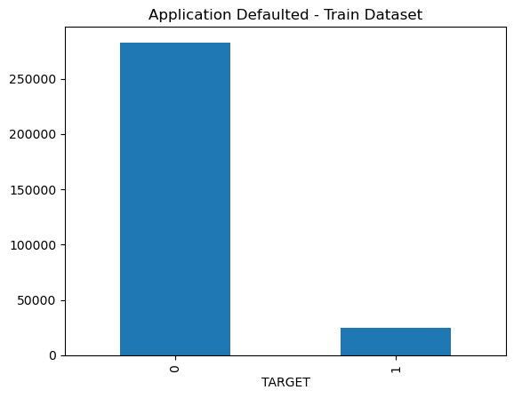

```python
app_train_data['TARGET'].value_counts().plot.bar(title='Application Defaulted - Train Dataset')
```

# Target Variable Relationships

Questions:

1. How many applicants per category on a predictor?
2. What's the percentage of DEFAULT per category on a predictor?
3. Is there a relationship between the TARGET and the predictor?

```python
def plot_var_rel(data, col_name):
    df_count = data[col_name].value_counts()
    df_percent = data[['TARGET', col_name]].groupby([col_name], as_index=False).mean() \
        .sort_values(by='TARGET', ascending = False)
    fig, axes = plt.subplots(1, 2, figsize=(10, 4))
    df_count.plot(ax = axes[0], kind = 'bar', x=col_name, ylabel='Count', title="Count of applicants by " + col_name)
    df_percent.plot(ax = axes[1], kind = 'bar', x=col_name, ylabel='Percent', title='Percent of Default [1] by '+ col_name)

def plot_var_rel_cont(data, col_name):
    df_count = data[col_name].value_counts()
    df_percent = data[['TARGET', col_name]].groupby([col_name], as_index=False).mean() \
        .sort_values(by='TARGET', ascending = False)
    df_count.plot(x=col_name)
    df_percent.plot(x=col_name)
```

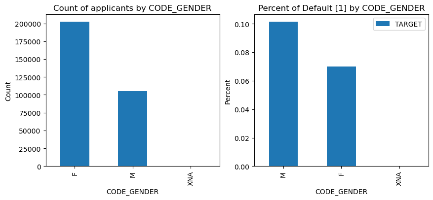

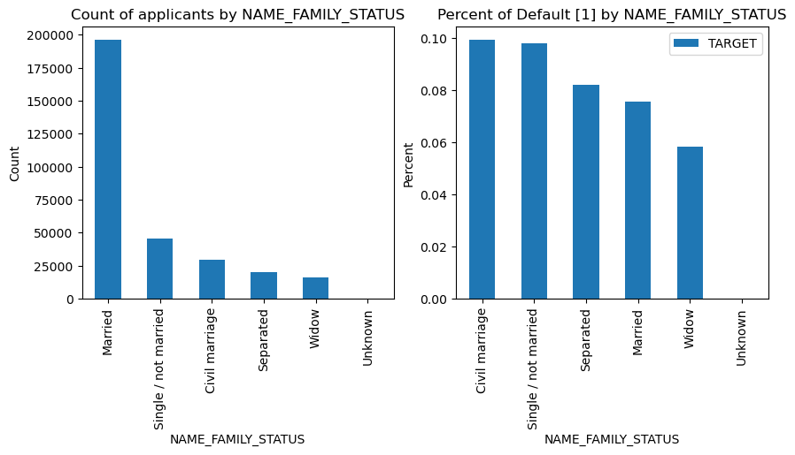

```python
plot_var_rel(app_train_data, 'CODE_GENDER')
plot_var_rel(app_train_data, 'NAME_FAMILY_STATUS')
```

#### Notes:

From the graphs, there are more female than male applicants. However, males tend to have defaulted likely than females.

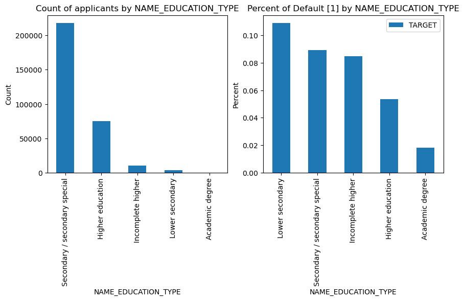

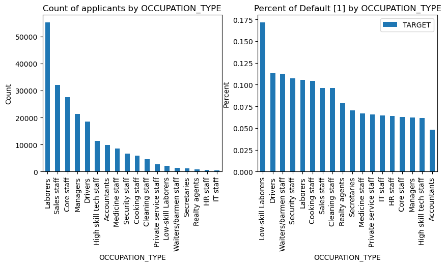

```python
plot_var_rel(app_train_data, 'NAME_EDUCATION_TYPE')
plot_var_rel(app_train_data, 'OCCUPATION_TYPE')
```

#### Notes:

Most applicants have either a secondary education or higher. Those who are lower education tend to default more than others.

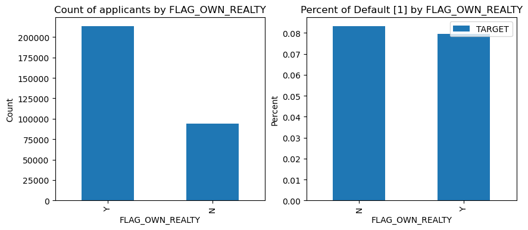

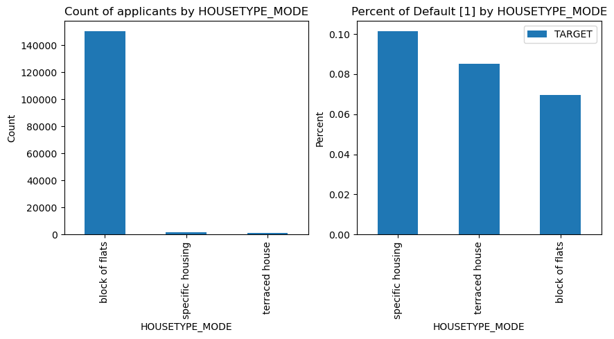

```python
plot_var_rel(app_train_data, 'FLAG_OWN_REALTY')
plot_var_rel(app_train_data, 'HOUSETYPE_MODE')
```

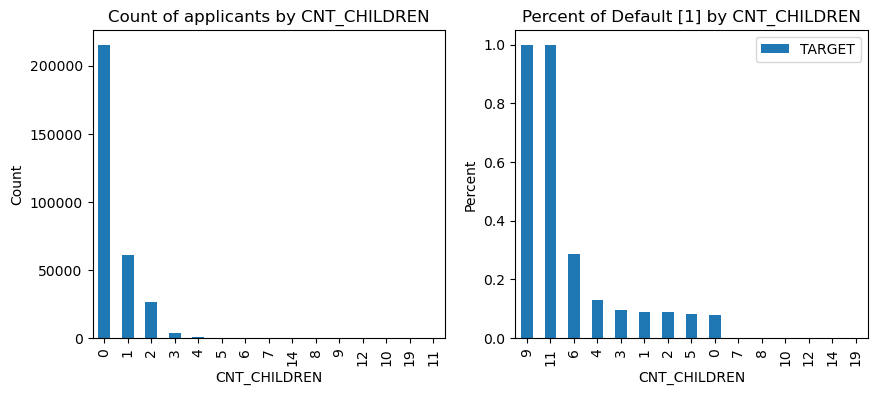

```python
plot_var_rel(app_train_data, 'CNT_CHILDREN')
```

#### Notes:

# Merging Application Data and Bureau Data

```python
app_train_bureau_data = app_train_data.merge(bureau_data, left_on='SK_ID_CURR', right_on='SK_ID_CURR', how='inner')
```

```python
describe_data(app_train_bureau_data).transpose()
```

```
Columns: 138
Rows: 1465325
```

|  | SK_ID_CURR | TARGET | CNT_CHILDREN | AMT_INCOME_TOTAL | AMT_CREDIT | AMT_ANNUITY_x | AMT_GOODS_PRICE | REGION_POPULATION_RELATIVE | DAYS_BIRTH | DAYS_EMPLOYED | ... | DAYS_CREDIT_ENDDATE | DAYS_ENDDATE_FACT | AMT_CREDIT_MAX_OVERDUE | CNT_CREDIT_PROLONG | AMT_CREDIT_SUM | AMT_CREDIT_SUM_DEBT | AMT_CREDIT_SUM_LIMIT | AMT_CREDIT_SUM_OVERDUE | DAYS_CREDIT_UPDATE | AMT_ANNUITY_y |
| --- | --- | --- | --- | --- | --- | --- | --- | --- | --- | --- | --- | --- | --- | --- | --- | --- | --- | --- | --- | --- | --- |
| count | 1.465325e+06 | 1.465325e+06 | 1.465325e+06 | 1.465325e+06 | 1.465325e+06 | 1.465283e+06 | 1.464198e+06 | 1.465325e+06 | 1.465325e+06 | 1.465325e+06 | ... | 1.376227e+06 | 920652.000000 | 5.167800e+05 | 1.465325e+06 | 1.465322e+06 | 1.242231e+06 | 9.756550e+05 | 1.465325e+06 | 1.465325e+06 | 3.353120e+05 |
| mean | 2.783285e+05 | 7.815331e-02 | 4.251494e-01 | 1.806372e+05 | 6.235979e+05 | 2.744757e+04 | 5.619748e+05 | 2.037588e-02 | -1.632260e+04 | 6.173365e+04 | ... | 4.931322e+02 | -1022.765286 | 3.942852e+03 | 7.278249e-03 | 3.516889e+05 | 1.358890e+05 | 6.363687e+03 | 4.010547e+01 | -5.997869e+02 | 1.576301e+04 |
| std | 1.029193e+05 | 2.684128e-01 | 7.240914e-01 | 2.229945e+05 | 4.090199e+05 | 1.421431e+04 | 3.761908e+05 | 1.321205e-02 | 4.167092e+03 | 1.398898e+05 | ... | 4.964905e+03 | 718.371749 | 2.196856e+05 | 1.026408e-01 | 1.078009e+06 | 6.756650e+05 | 4.543915e+04 | 6.273639e+03 | 7.371010e+02 | 2.681074e+05 |
| min | 1.000020e+05 | 0.000000e+00 | 0.000000e+00 | 2.610000e+04 | 4.500000e+04 | 1.615500e+03 | 4.050000e+04 | 2.900000e-04 | -2.520100e+04 | -1.791200e+04 | ... | -4.206000e+04 | -42023.000000 | 0.000000e+00 | 0.000000e+00 | 0.000000e+00 | -4.705600e+06 | -5.864061e+05 | 0.000000e+00 | -4.194700e+04 | 0.000000e+00 |
| 25% | 1.889700e+05 | 0.000000e+00 | 0.000000e+00 | 1.125000e+05 | 2.844000e+05 | 1.687500e+04 | 2.475000e+05 | 1.000600e-02 | -1.981400e+04 | -3.201000e+03 | ... | -1.144000e+03 | -1503.000000 | 0.000000e+00 | 0.000000e+00 | 5.116500e+04 | 0.000000e+00 | 0.000000e+00 | 0.000000e+00 | -9.040000e+02 | 0.000000e+00 |
| 50% | 2.782890e+05 | 0.000000e+00 | 0.000000e+00 | 1.575000e+05 | 5.387040e+05 | 2.534850e+04 | 4.545000e+05 | 1.880100e-02 | -1.597100e+04 | -1.486000e+03 | ... | -3.340000e+02 | -900.000000 | 0.000000e+00 | 0.000000e+00 | 1.246981e+05 | 0.000000e+00 | 0.000000e+00 | 0.000000e+00 | -4.060000e+02 | 6.750000e+01 |
| 75% | 3.674940e+05 | 0.000000e+00 | 1.000000e+00 | 2.250000e+05 | 8.356050e+05 | 3.516075e+04 | 7.110000e+05 | 2.639200e-02 | -1.293800e+04 | -3.610000e+02 | ... | 4.730000e+02 | -427.000000 | 0.000000e+00 | 0.000000e+00 | 3.082500e+05 | 3.965400e+04 | 0.000000e+00 | 0.000000e+00 | -3.300000e+01 | 1.399050e+04 |
| max | 4.562550e+05 | 1.000000e+00 | 1.900000e+01 | 1.170000e+08 | 4.050000e+06 | 2.580255e+05 | 4.050000e+06 | 7.250800e-02 | -7.489000e+03 | 3.652430e+05 | ... | 3.119900e+04 | 0.000000 | 1.159872e+08 | 9.000000e+00 | 3.960000e+08 | 1.701000e+08 | 4.705600e+06 | 3.756681e+06 | 3.720000e+02 | 5.958668e+07 |

8 rows × 119 columns

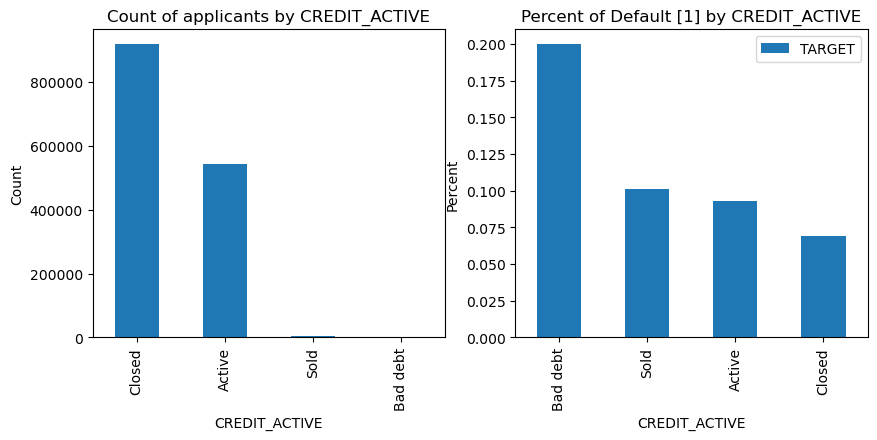

```python
plot_var_rel(app_train_bureau_data, 'CREDIT_ACTIVE')
```

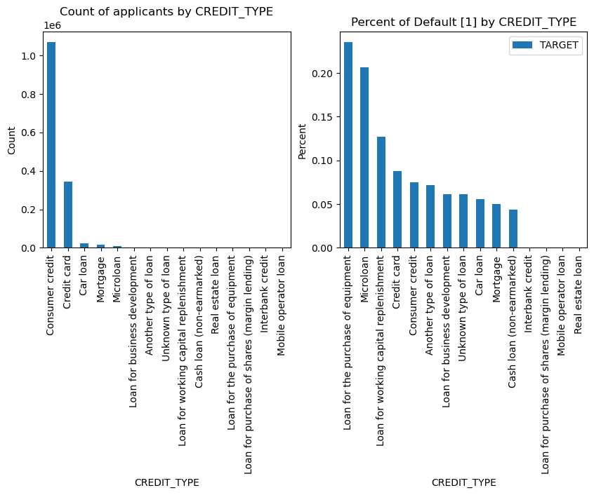

```python
plot_var_rel(app_train_bureau_data, 'CREDIT_TYPE')
```

# Results:

As we delve deeper into the datasets, it has come to our attention that there are several instances of missing data that need to be addressed. Specifically, columns with 40% or more missing data will be removed from the dataset. For those columns with missing data below this threshold, we will employ imputation techniques such as filling in the missing values with either the mean or median, depending on the nature of the predictor variable.

It's important to note that the train and test datasets exhibit slight variations in the percentage of missing data, but these differences are minimal and can be managed effectively.

Additionally, there are columns within the dataset that need to be redefined as categorical variables, rather than retaining their current float or continuous data type. This adjustment is crucial for accurately representing the nature of these variables in the modeling process.

During our data exploration, we have identified several predictors that have a substantial impact on the target variable. These influential predictors will be a key focus in our modeling efforts, as they are likely to play a significant role in the predictive accuracy of our models.

Furthermore, we have observed that the dataset suffers from class imbalance, meaning that the distribution of the target variable is skewed, with one class being significantly more prevalent than the others. Addressing this imbalance is critical to ensure that our models do not disproportionately favor the majority class and provide a more balanced prediction.

In conclusion, the dataset is now primed for the next stage of our analysis, where we will fit various models using the training dataset. These models will take into account the preprocessing steps, such as handling missing data, redefining categorical variables, and addressing class imbalance, to provide robust predictions for our target variable. This comprehensive approach will help us achieve more accurate and meaningful results in our analysis.